# Advanced Tree Models – Bagging Tree

In this lab, we will cover some state-of-the-art techniques in the framework of tree models. We use the same datasets as in previous lab, Boston Housing data and Credit Scoring data.

```r
# load Boston data
library(MASS)
data(Boston)
index <- sample(nrow(Boston),nrow(Boston)*0.60)
boston.train <- Boston[index,]
boston.test <- Boston[-index,]

# load credit card data
credit.data <- read.csv("data/credit_default.csv", header=T)
# convert categorical variables
credit.data$SEX<- as.factor(credit.data$SEX)
credit.data$EDUCATION<- as.factor(credit.data$EDUCATION)
credit.data$MARRIAGE<- as.factor(credit.data$MARRIAGE)
# random splitting
index <- sample(nrow(credit.data),nrow(credit.data)*0.60)
credit.train = credit.data[index,]
credit.test = credit.data[-index,]
```

# 1 Bagging

*Bagging* stands for Bootstrap and Aggregating. It employs the idea of bootstrap but the purpose is not to study bias and standard errors of estimates. Instead, the goal of Bagging is to improve prediction accuracy. It fits a tree for each bootsrap sample, and then aggregate the predicted values from all these different trees. For more details, you may look at [Wikepedia](https://en.wikipedia.org/wiki/Bootstrap_aggregating), or you can find the original paper [Leo Breiman (1996)](https://link.springer.com/content/pdf/10.1007/BF00058655.pdf).

An available R package, `ipred`, provides functions to perform Bagging. You need to install this package if you didn’t do it before.

```r
library(ipred)
```

## 1.1 Bagging for regression tree.

Fit tree with bagging on Boston training data, and calculate MSE on testing sample.

```r
boston.bag<- bagging(medv~., data = boston.train, nbagg=100)
boston.bag
```

```
##
## Bagging regression trees with 100 bootstrap replications
##
## Call: bagging.data.frame(formula = medv ~ ., data = boston.train, nbagg = 100)
```

Prediction on testing sample.

```r
boston.bag.pred<- predict(boston.bag, newdata = boston.test)
mean((boston.test$medv-boston.bag.pred)^2)
```

```
## [1] 23.12812
```

Comparing with a single tree.

```r
library(rpart)
boston.tree<- rpart(medv~., data = boston.train)
boston.tree.pred<- predict(boston.tree, newdata = boston.test)
mean((boston.test$medv-boston.tree.pred)^2)
```

```
## [1] 28.23399
```

How many trees are good?

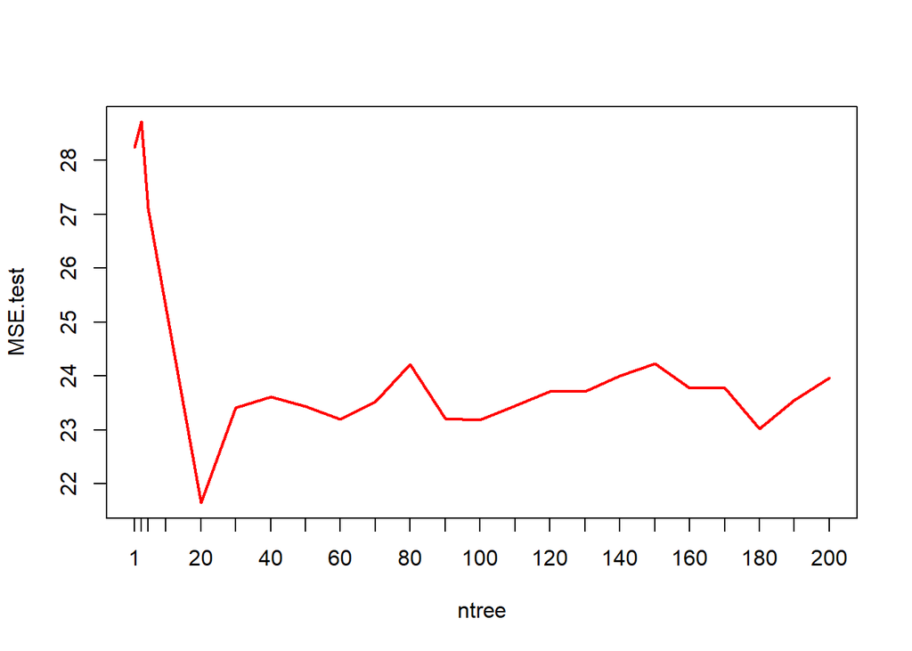

```r
ntree<- c(1, 3, 5, seq(10, 200, 10))
MSE.test<- rep(0, length(ntree))
for(i in 1:length(ntree)){
  boston.bag1<- bagging(medv~., data = boston.train, nbagg=ntree[i])
  boston.bag.pred1<- predict(boston.bag1, newdata = boston.test)
  MSE.test[i]<- mean((boston.test$medv-boston.bag.pred1)^2)
}
plot(ntree, MSE.test, type = 'l', col=2, lwd=2, xaxt="n")
axis(1, at = ntree, las=1)
```

By fitting the Bagging multiple times and predicting the testing sample, we can draw the following boxplot to show the variance of the prediction error at different number of trees.

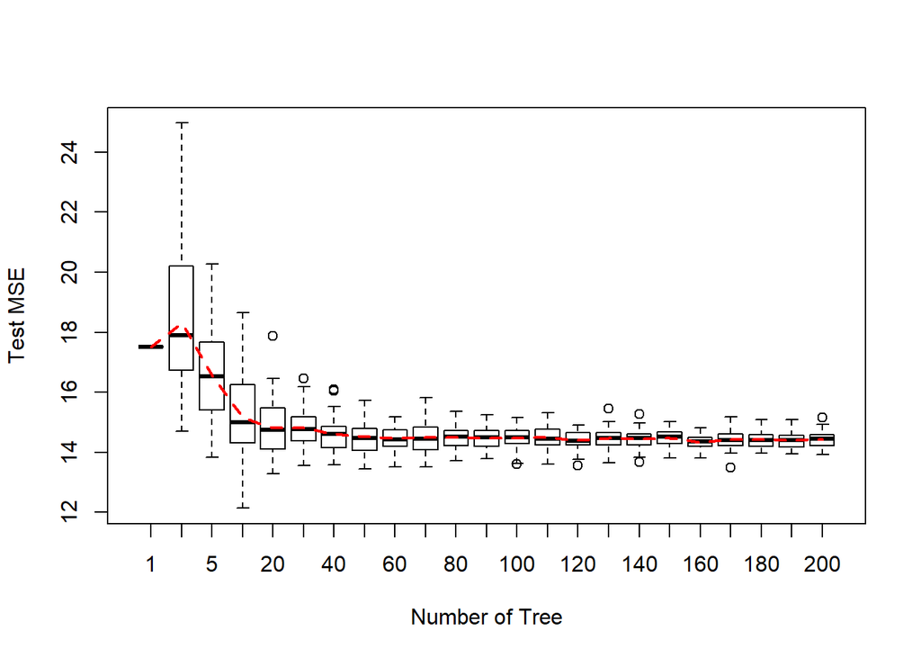

## 1.2 Out-of-bag (OOB) prediction

The out-of-bag prediction is similar to LOOCV. We use full sample. In every bootstrap, the unused sample serves as testing sample, and testing error is calculated. In the end, OOB error, root mean squared error by default, is obtained

```r
boston.bag.oob<- bagging(medv~., data = boston.train, coob=T, nbagg=100)
boston.bag.oob
```

```
##
## Bagging regression trees with 100 bootstrap replications
##
## Call: bagging.data.frame(formula = medv ~ ., data = boston.train, coob = T,
##     nbagg = 100)
##
## Out-of-bag estimate of root mean squared error:  3.8234
```

## 1.3 Bagging for classification tree.

To my best knowledge, it seems that `bagging()` won’t take an argument for asymmetric loss. Therefore, the classification results might not be appropriate.

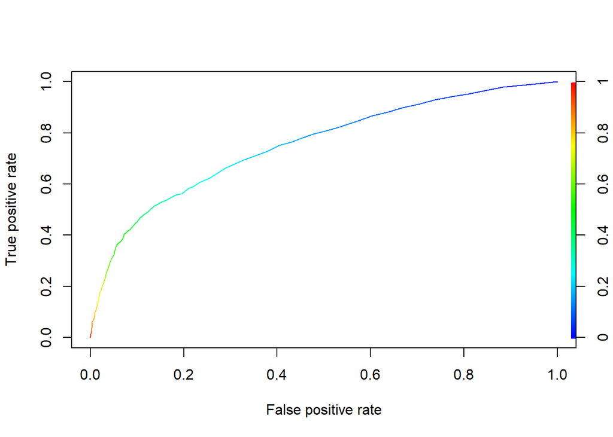

```r
credit.bag<- bagging(as.factor(default.payment.next.month)~., data = credit.train, nbagg=100)
credit.bag.pred<- predict(credit.bag, newdata = credit.train, type="prob")[,2]
credit.bag.pred.test<- predict(credit.bag, newdata = credit.test, type="prob")[,2]
library(ROCR)
pred = prediction(credit.bag.pred.test, credit.test$default.payment.next.month)
perf = performance(pred, "tpr", "fpr")
plot(perf, colorize=TRUE)
```

```r
unlist(slot(performance(pred, "auc"), "y.values"))
```

```
## [1] 0.7537531
```

The classification results are generated by specifying `type="class"`.

```r
credit.bag.pred.test<- predict(credit.bag, newdata = credit.test, type="class")
table(credit.test$default.payment.next.month, credit.bag.pred.test, dnn = c("True", "Pred"))
```

```
##     Pred
## True    0    1
##    0 3476  244
##    1  674  406
```

```r
costMatrix <- matrix(c(0,35,1,0), nrow=2)
credit_asy_bag<- bagging(as.factor(default.payment.next.month)~.,
                         data = credit.train,
                         parms=list(cost=costMatrix), nbagg=100)
credit_asy_bag_pred<- predict(credit_asy_bag, newdata = credit.test)
table(credit.test$default.payment.next.month, credit_asy_bag_pred, dnn = c("True", "Pred"))
```

```
##     Pred
## True    0    1
##    0 3479  241
##    1  680  400
```

- Question: What will you see if you calculate the AUC of training set?

```r
predtrain = prediction(credit.bag.pred, credit.train$default.payment.next.month)
perftrain = performance(predtrain, "tpr", "fpr")
plot(perftrain, colorize=TRUE)
unlist(slot(performance(predtrain, "auc"), "y.values"))

credit.bag.pred.train <- predict(credit.bag, newdata = credit.train, type="class")
table(credit.train$default.payment.next.month, credit.bag.pred.train, dnn = c("True", "Pred"))
```

Comparing with a single tree. For fair comparison, we assume the loss is symmetric.

```r
credit.rpart <- rpart(formula = default.payment.next.month ~ ., data = credit.train, method = "class")
credit.test.pred.tree1 <- predict(credit.rpart, credit.test, type="class")
table(credit.test$default.payment.next.month, credit.test.pred.tree1, dnn=c("Truth","Predicted"))
```

```
##      Predicted
## Truth    0    1
##     0 3561  159
##     1  722  358
```

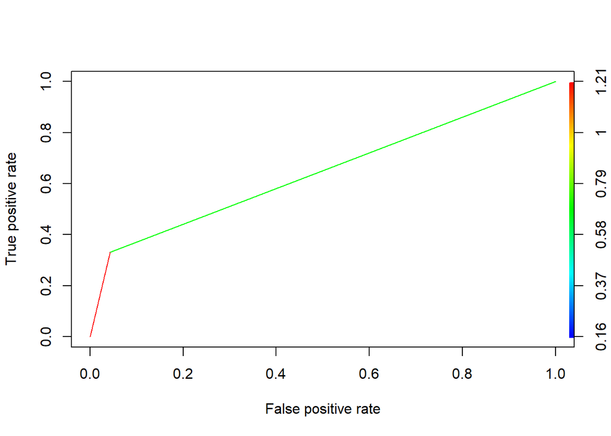

```r
credit.test.pred.tree1 <- predict(credit.rpart, credit.test, type="prob")

pred = prediction(credit.test.pred.tree1[,2], credit.test$default.payment.next.month)
perf = performance(pred, "tpr", "fpr")
plot(perf, colorize=TRUE)
```

```r
unlist(slot(performance(pred, "auc"), "y.values"))
```

```
## [1] 0.6443698
```